# Final Assignment, Section 1 - Task 2

Arash Heidarzadeh Naeini u3236906

05/05/2025

```r
# Load necessary libraries
library(dplyr)
library(ggplot2)
library(lubridate)
library(scales)
library(tidyr)
options(ggplot2.deprecated.inform = FALSE)
# Read the cleaned data file
covid19_clean <- read.csv("covid19_clean.csv")

# Ensure date is in the proper format
covid19_clean$Date <- as.Date(covid19_clean$Date)
```

# Task 1: Data Preparation and Wrangling:

## 1. Find the day with the highest death toll reported across the world. Print the date and the death toll of that day.

```r
# 1. Find the day with highest death toll reported across the world
highest_death_day <- covid19_clean %>%
  group_by(Date) %>%
  summarize(TotalDeaths = sum(NewDeaths, na.rm = TRUE)) %>%
  arrange(desc(TotalDeaths)) %>%
  head(1)

cat("The day with highest death toll was", format(highest_death_day$Date, "%d/%m/%Y"),
    "with", highest_death_day$TotalDeaths, "deaths.\n")
```

```
## The day with highest death toll was 16/04/2020 with 10520 deaths.
```

## 2. Build a graph to show how the cumulative data of (Infected Cases, Deaths, Recovered, Tests) change over the time for the whole world collectively.

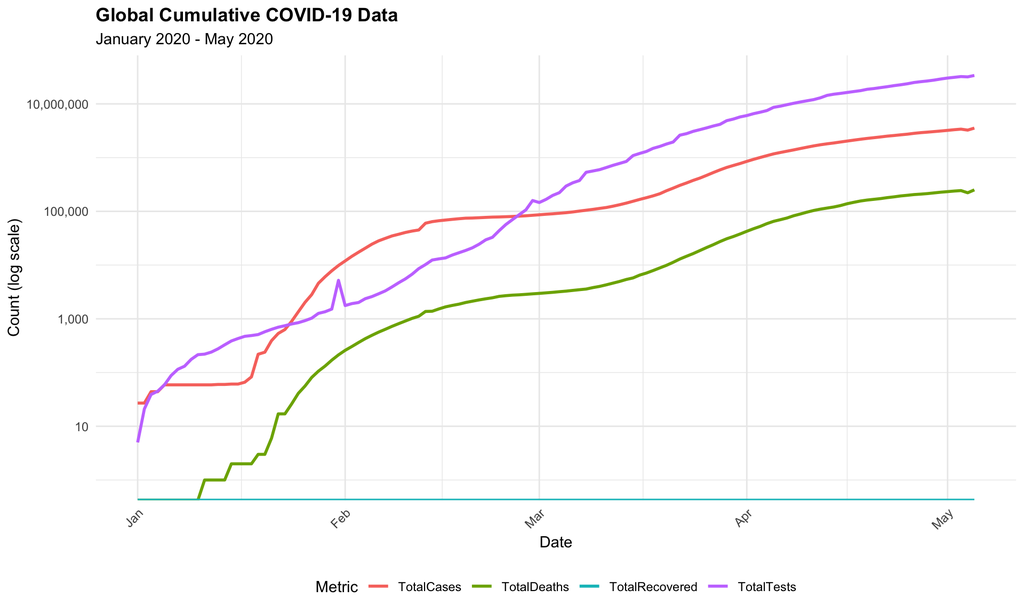

```r
world_cumulative <- covid19_clean %>%
  group_by(Date) %>%
  summarize(
    TotalCases = sum(CumCases, na.rm = TRUE),
    TotalDeaths = sum(CumDeaths, na.rm = TRUE),
    TotalRecovered = sum(CumRecovered, na.rm = TRUE),
    TotalTests = sum(CumTests, na.rm = TRUE)
  )

# Convert to long format for plotting
world_cumulative_long <- pivot_longer(
  world_cumulative,
  cols = c(TotalCases, TotalDeaths, TotalRecovered, TotalTests),
  names_to = "Metric",
  values_to = "Count"
)

# Create the plot
p2 <- ggplot(world_cumulative_long, aes(x = Date, y = Count, color = Metric)) +
  geom_line(linewidth = 1) +
  scale_y_log10(labels = comma) +
  labs(
    title = "Global Cumulative COVID-19 Data",
    subtitle = "January 2020 - May 2020",
    x = "Date",
    y = "Count (log scale)",
    color = "Metric"
  ) +
  theme_minimal() +
  theme(
    legend.position = "bottom",
    plot.title = element_text(face = "bold"),
    axis.text.x = element_text(angle = 45, hjust = 1)
  )

print(p2)
```

## 3. Extract the data corresonding to the last day (05/05/2020) for all countries and save it in a separate dataframe and name it “lastDay_data”.

```r
# 3. Extract data for the last day (May 5, 2020)
lastDay_data <- covid19_clean %>%
  filter(Date == as.Date("2020-05-05"))

# Save to a file if needed
write.csv(lastDay_data, "lastDay_data.csv", row.names = FALSE)
```

## 4. Based on the data in “lastDay_data” dataframe, extract the corresponding records of the top 10 countries worldwide with current active cases, total confirmed cases, or fatality rate in separate dataframes (i.e., top10activeW, top10casesW, top10fatalityW, top10testsMW).

```r
top10activeW <- lastDay_data %>%
  arrange(desc(Active)) %>%
  head(10)

top10casesW <- lastDay_data %>%
  arrange(desc(CumCases)) %>%
  head(10)

top10fatalityW <- lastDay_data %>%
  filter(CumCases > 1000) %>%  # Filter to avoid countries with few cases but high fatality
  arrange(desc(FatalityRate)) %>%
  head(10)

top10testsMW <- lastDay_data %>%
  arrange(desc(Tests_1M_Pop)) %>%
  head(10)
```

## 5. Based on the data of the in “lastDay_data” dataframe, print total confirmed cases, death, recovered cases as well as the total tests per every continent.

```r
continent_summary <- lastDay_data %>%
  group_by(Continent) %>%
  summarize(
    TotalCases = sum(CumCases, na.rm = TRUE),
    TotalDeaths = sum(CumDeaths, na.rm = TRUE),
    TotalRecovered = sum(CumRecovered, na.rm = TRUE),
    TotalTests = sum(CumTests, na.rm = TRUE)
  )

print(continent_summary)
```

```
## # A tibble: 6 × 5
##   Continent     TotalCases TotalDeaths TotalRecovered TotalTests
##   <chr>              <int>       <int>          <int>      <int>
## 1 Africa             47124        1845              0     618154
## 2 Asia              567862       19991              0    6010340
## 3 Europe           1406374      141780              0   17013488
## 4 North America    1290176       75981              0    8447832
## 5 Oceania             8579         122              0     820684
## 6 South America     223752       11251              0     919018
```

## 6. Build a graph to show the total number of cases over the time for the top 10 countries that have been obtained in question 4 (Use log transformation for the values in Y axis for better presentation).

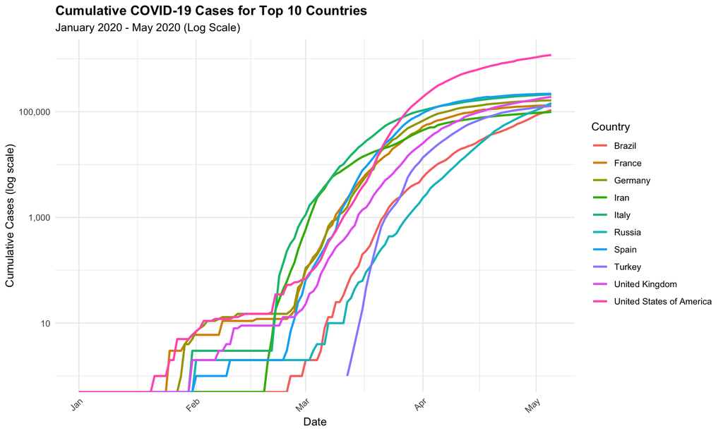

```r
# 6. Graph showing total cases over time for top 10 countries by cases
top10_countries_cases <- top10casesW$Country

cases_over_time <- covid19_clean %>%
  filter(Country %in% top10_countries_cases) %>%
  select(Country, Date, CumCases)

p6 <- ggplot(cases_over_time, aes(x = Date, y = CumCases, color = Country)) +
  geom_line(linewidth = 1) +
  scale_y_log10(labels = comma) +
  labs(
    title = "Cumulative COVID-19 Cases for Top 10 Countries",
    subtitle = "January 2020 - May 2020 (Log Scale)",
    x = "Date",
    y = "Cumulative Cases (log scale)",
    color = "Country"
  ) +
  theme_minimal() +
  theme(
    legend.position = "right",
    plot.title = element_text(face = "bold"),
    axis.text.x = element_text(angle = 45, hjust = 1)
  )

print(p6)
```

## 7. Build a graph for the top 10 countries with current highest active cases which was obtained previously in question 4. The graph should have one sub-graph (i.e., using facet function) for each of these countries, every sub-graph should show how the new cases, new deaths, and new recovered cases were changing over the time (Use log for Y axis for better presentation, Use different colour to distinguish between new cases, deaths, and recovered).

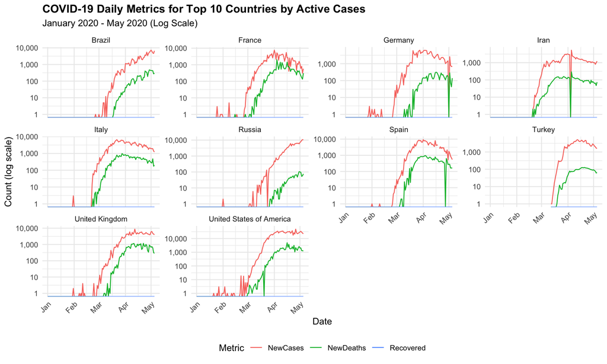

```r
# 7. Graph with subplots for top 10 countries with highest active cases
top10_countries_active <- top10activeW$Country

active_countries_data <- covid19_clean %>%
  filter(Country %in% top10_countries_active) %>%
  select(Country, Date, NewCases, NewDeaths, Recovered)

# Convert to long format for faceting
active_countries_long <- pivot_longer(
  active_countries_data,
  cols = c(NewCases, NewDeaths, Recovered),
  names_to = "Metric",
  values_to = "Count"
)

p7 <- ggplot(active_countries_long, aes(x = Date, y = Count, color = Metric)) +
  geom_line() +
  scale_y_log10(labels = comma) +
  facet_wrap(~ Country, scales = "free_y") +
  labs(
    title = "COVID-19 Daily Metrics for Top 10 Countries by Active Cases",
    subtitle = "January 2020 - May 2020 (Log Scale)",
    x = "Date",
    y = "Count (log scale)",
    color = "Metric"
  ) +
  theme_minimal() +
  theme(
    legend.position = "bottom",
    plot.title = element_text(face = "bold"),
    axis.text.x = element_text(angle = 45, hjust = 1)
  )

print(p7)
```

## 8. Build a graph for the top 10 countries with current highest total tests per one million of the population which was obtained previously in question 4. This graph should present total number of infected cases, total tests so far, and the total tests per million of the population for each country.

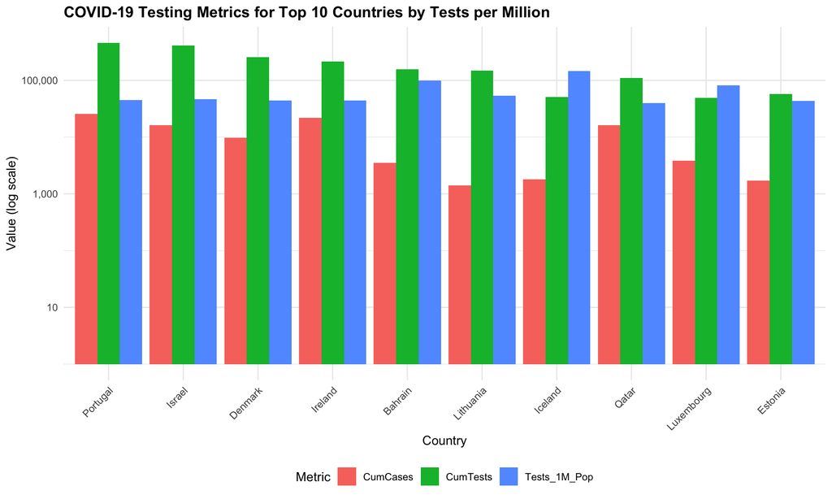

```r
# 8. Bar chart for top 10 countries with highest tests per million
top10_tests_data <- lastDay_data %>%
  filter(Country %in% top10testsMW$Country) %>%
  select(Country, CumCases, CumTests, Tests_1M_Pop) %>%
  arrange(desc(Tests_1M_Pop))

# Convert to long format for grouped bars
top10_tests_long <- pivot_longer(
  top10_tests_data,
  cols = c(CumCases, CumTests, Tests_1M_Pop),
  names_to = "Metric",
  values_to = "Value"
)

p8 <- ggplot(top10_tests_long, aes(x = reorder(Country, -Value), y = Value, fill = Metric)) +
  geom_bar(stat = "identity", position = "dodge") +
  scale_y_log10(labels = comma) +
  labs(
    title = "COVID-19 Testing Metrics for Top 10 Countries by Tests per Million",
    x = "Country",
    y = "Value (log scale)",
    fill = "Metric"
  ) +
  theme_minimal() +
  theme(
    legend.position = "bottom",
    plot.title = element_text(face = "bold"),
    axis.text.x = element_text(angle = 45, hjust = 1)
  )

print(p8)
```

## 9. Build a graph to present the statistics total, average, median of confirmed cases of the continents. ( you may use log for Y axis for better presentation, Use Continent in the legend, make sure x-axis labels does not overlap).

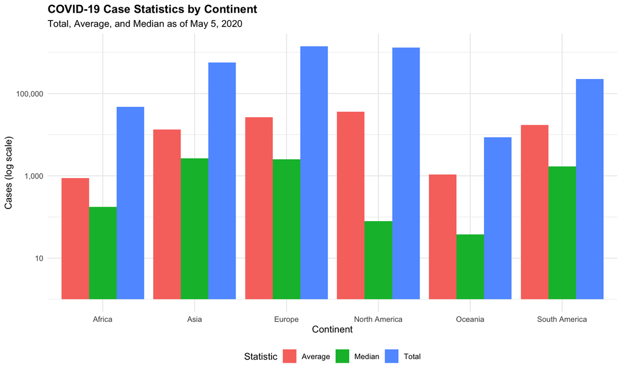

```r
# 9. Graph for continent statistics
continent_stats <- lastDay_data %>%
  group_by(Continent) %>%
  summarize(
    Total = sum(CumCases, na.rm = TRUE),
    Average = mean(CumCases, na.rm = TRUE),
    Median = median(CumCases, na.rm = TRUE)
  ) %>%
  pivot_longer(
    cols = c(Total, Average, Median),
    names_to = "Statistic",
    values_to = "Value"
  )

p9 <- ggplot(continent_stats, aes(x = Continent, y = Value, fill = Statistic)) +
  geom_bar(stat = "identity", position = "dodge") +
  scale_y_log10(labels = comma) +
  labs(
    title = "COVID-19 Case Statistics by Continent",
    subtitle = "Total, Average, and Median as of May 5, 2020",
    x = "Continent",
    y = "Cases (log scale)",
    fill = "Statistic"
  ) +
  theme_minimal() +
  theme(
    legend.position = "bottom",
    plot.title = element_text(face = "bold"),
    axis.text.x = element_text(angle = 0)
  )

print(p9)
```

## 10. Based on the data of the “lastDay_data” dataframe, list the top 2-countries of each continent that report the highest death toll.

```r
# 10. Top 2 countries with highest death toll in each continent
top_deaths_by_continent <- lastDay_data %>%
  group_by(Continent) %>%
  arrange(desc(CumDeaths)) %>%
  slice_head(n = 2) %>%
  select(Continent, Country, CumDeaths) %>%
  arrange(Continent, desc(CumDeaths))

print(top_deaths_by_continent)
```

```
## # A tibble: 12 × 3
## # Groups:   Continent [6]
##    Continent     Country                  CumDeaths
##    <chr>         <chr>                        <int>
##  1 Africa        Algeria                        465
##  2 Africa        Egypt                          436
##  3 Asia          Iran                          6277
##  4 Asia          China                         4637
##  5 Europe        Italy                        29079
##  6 Europe        United Kingdom               28734
##  7 North America United States of America     68934
##  8 North America Canada                        3854
##  9 Oceania       Australia                       95
## 10 Oceania       New Zealand                     20
## 11 South America Brazil                        7321
## 12 South America Ecuador                       1569
```

### 11- Summary and Report

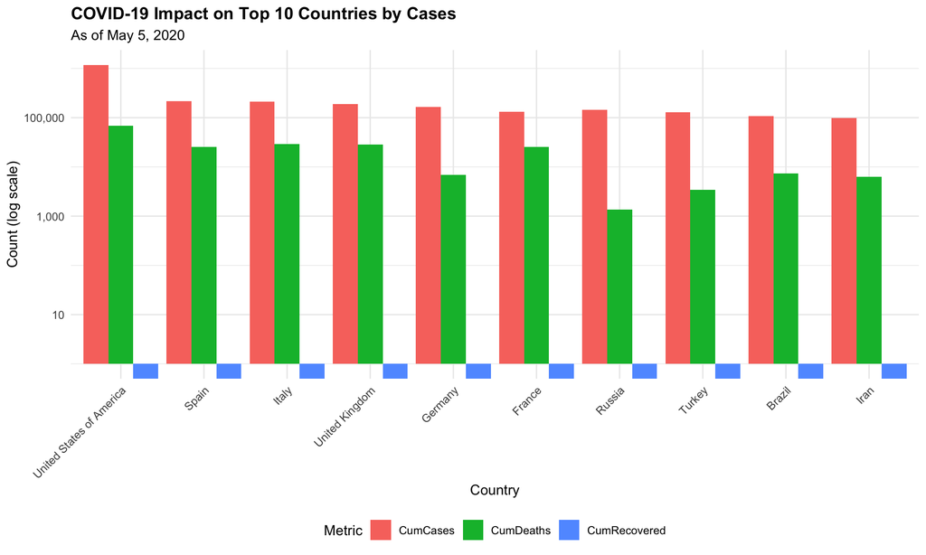

```r
# Below is the code to generate any final visualizations for the report

# Create a comprehensive bar chart showing the top 10 countries by cases with deaths and recoveries
top10_comprehensive <- lastDay_data %>%
  filter(Country %in% top10casesW$Country) %>%
  select(Country, CumCases, CumDeaths, CumRecovered) %>%
  arrange(desc(CumCases))

# Convert to long format for grouped bars
top10_comprehensive_long <- pivot_longer(
  top10_comprehensive,
  cols = c(CumCases, CumDeaths, CumRecovered),
  names_to = "Metric",
  values_to = "Value"
)

p11a <- ggplot(top10_comprehensive_long, aes(x = reorder(Country, -Value), y = Value, fill = Metric)) +
  geom_bar(stat = "identity", position = "dodge") +
  scale_y_log10(labels = comma) +
  labs(
    title = "COVID-19 Impact on Top 10 Countries by Cases",
    subtitle = "As of May 5, 2020",
    x = "Country",
    y = "Count (log scale)",
    fill = "Metric"
  ) +
  theme_minimal() +
  theme(
    legend.position = "bottom",
    plot.title = element_text(face = "bold"),
    axis.text.x = element_text(angle = 45, hjust = 1)
  )

print(p11a)
```

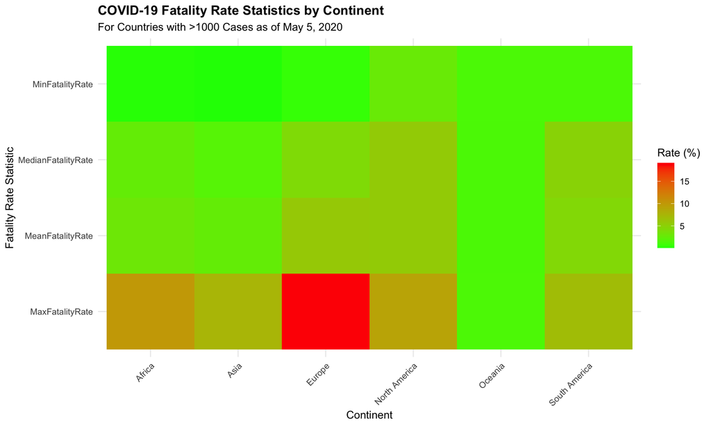

```r
# Create a heatmap of case fatality rates by continent
fatality_heatmap_data <- lastDay_data %>%
  filter(CumCases > 1000) %>%  # Filter to countries with significant cases
  group_by(Continent) %>%
  summarize(
    MinFatalityRate = min(FatalityRate, na.rm = TRUE),
    MedianFatalityRate = median(FatalityRate, na.rm = TRUE),
    MeanFatalityRate = mean(FatalityRate, na.rm = TRUE),
    MaxFatalityRate = max(FatalityRate, na.rm = TRUE)
  ) %>%
  pivot_longer(
    cols = c(MinFatalityRate, MedianFatalityRate, MeanFatalityRate, MaxFatalityRate),
    names_to = "Statistic",
    values_to = "Rate"
  )

p11b <- ggplot(fatality_heatmap_data, aes(x = Continent, y = Statistic, fill = Rate)) +
  geom_tile() +
  scale_fill_gradient(low = "green", high = "red") +
  labs(
    title = "COVID-19 Fatality Rate Statistics by Continent",
    subtitle = "For Countries with >1000 Cases as of May 5, 2020",
    x = "Continent",
    y = "Fatality Rate Statistic",
    fill = "Rate (%)"
  ) +
  theme_minimal() +
  theme(
    plot.title = element_text(face = "bold"),
    axis.text.x = element_text(angle = 45, hjust = 1)
  )

print(p11b)
```

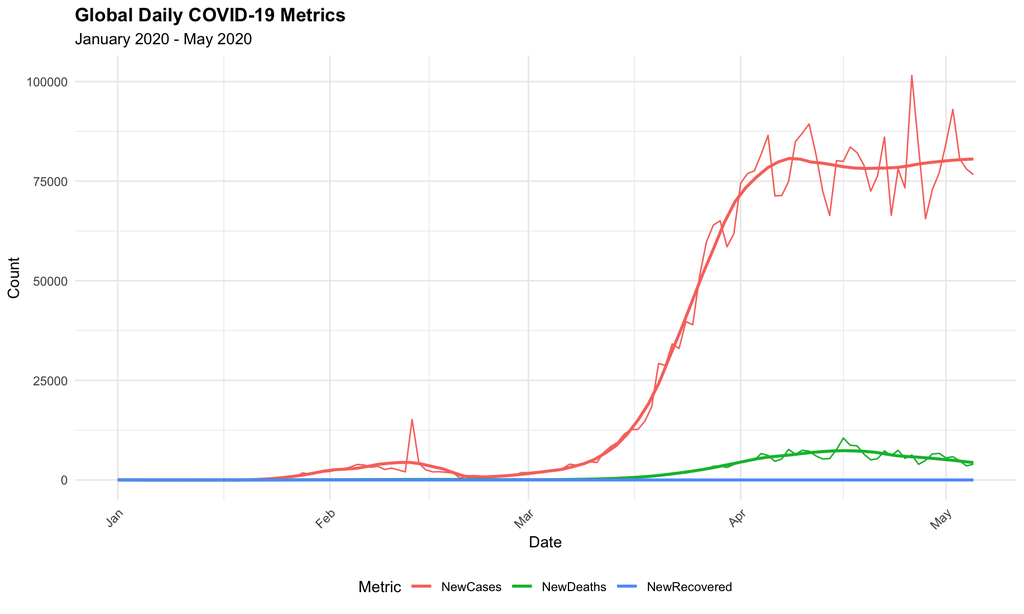

```r
# Create a final time series showing the global daily new cases, deaths, and recoveries
global_daily <- covid19_clean %>%
  group_by(Date) %>%
  summarize(
    NewCases = sum(NewCases, na.rm = TRUE),
    NewDeaths = sum(NewDeaths, na.rm = TRUE),
    NewRecovered = sum(Recovered, na.rm = TRUE)
  )

# Convert to long format for plotting
global_daily_long <- pivot_longer(
  global_daily,
  cols = c(NewCases, NewDeaths, NewRecovered),
  names_to = "Metric",
  values_to = "Count"
)

p11c <- ggplot(global_daily_long, aes(x = Date, y = Count, color = Metric)) +
  geom_line() +
  geom_smooth(span = 0.2, se = FALSE, alpha = 0.5) +
  labs(
    title = "Global Daily COVID-19 Metrics",
    subtitle = "January 2020 - May 2020",
    x = "Date",
    y = "Count",
    color = "Metric"
  ) +
  theme_minimal() +
  theme(
    legend.position = "bottom",
    plot.title = element_text(face = "bold"),
    axis.text.x = element_text(angle = 45, hjust = 1)
  )

print(p11c)
```